# R Notebook

# Homework week 11 - day2

```r
library(GGally)
```

## Question 1

| pclass | sex | sib_sp | parch | embarked | survived | survived_flag | age_status |
| --- | --- | --- | --- | --- | --- | --- | --- |
| 3 | male | 0 | 0 | S | 0 | FALSE | adult |
| 3 | male | 0 | 0 | Q | 0 | FALSE | adult |
| 3 | female | 0 | 0 | S | 1 | TRUE | adult |
| 3 | male | 0 | 0 | S | 1 | TRUE | adult |
| 3 | female | 0 | 0 | S | 1 | TRUE | adult |
| 1 | female | 0 | 0 | S | 1 | TRUE | adult |
| 3 | female | 0 | 2 | C | 1 | TRUE | adult |
| 1 | male | 0 | 1 | S | 0 | FALSE | adult |
| 1 | female | 0 | 1 | C | 1 | TRUE | adult |
| 2 | male | 1 | 0 | C | 0 | FALSE | adult |

[output cut: 704 more lines]

## Question 2

Have a look at your data and create some plots to ensure you know what you’re working with before you begin. Write a summary of what you have found in your plots. Which variables do you think might be useful to predict whether or not people are going to die? Knowing this before you start is the best way to have a sanity check that your model is doing a good job.

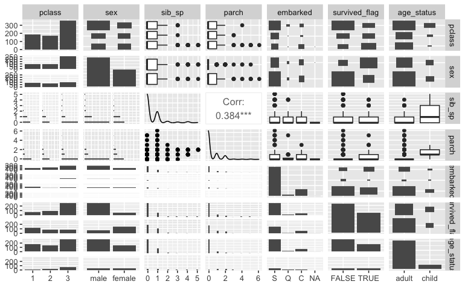

Based on the GGpairs plot, looking at survived column it looks like: sex -> gives a good indication if someone will survive age_status -> good indication pclass -> gives a reasonable indication

Not great indicators are: embarked, parch, and sib_sp

## Question 3

80% training, 20% saved for testing

```r
titanic_test %>%
  janitor::tabyl(survived_flag)
```

```
 survived_flag  n  percent
         FALSE 83 0.584507
          TRUE 59 0.415493
```

```r
titanic_train %>%
  janitor::tabyl(survived_flag)
```

```
 survived_flag   n   percent
         FALSE 341 0.5961538
          TRUE 231 0.4038462
```

## Question 4

Create your decision tree to try and predict survival probability using an appropriate method, and create a decision tree plot.

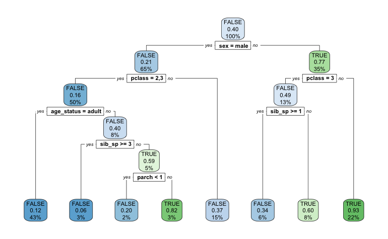

## Question 5

Write down what this tells you, in detail. What variables are important? What does each node tell you? Who has the highest chance of surviving? Who has the lowest? Provide as much detail as you can.

-> The decimal number gives the probability someone survived, given that they reach that leave While the proportion in % gives the total proportion of ‘observations’ at that point: the conditional probibility

Each node tells us: - predicted survival TRUE/FALSE at the top - decimal number gives us the probability of survival (of people meeting the conditions to reach this node) - % number, gives us the percentage of observations that pass through this node

So in short, the root gives us: 100% of the data/observations/passengers reach this point. 0.4 (=40%) meet the condition we are looking for (=survived_flag)

Highest chance of surviving: 0.93, with conditions: female in another pclass than 3

## Question 6

Test and add your predictions to your data. Create a confusion matrix. Write down in detail what this tells you for this specific dataset.

```r
conf_mat
```

```
          Truth
Prediction FALSE TRUE
     FALSE    75   18
     TRUE      8   41
```

Confusion matrix tells us: 1. that for observations we predicted ‘survival’: 41 did in reality survive, 8 did not. -> We have 8 false positives 2. of our predicted ‘not-survival’: 75 did not survive, and 18 did survive in reality. -> we have 18 false negatives

| .metric | .estimator | .estimate |
| --- | --- | --- |
| sensitivity | binary | 0.9036145 |

We can calculate the Specificity (true negative rate)

| .metric | .estimator | .estimate |
| --- | --- | --- |
| specificity | binary | 0.6949153 |